# Exploratory Data Analysis

Sophia Drewry

10/27/2021

This script loads performs an exploratory data analysis on data sets in the processed_data folder. All results can be found in the Exploratory Data Analysis folder in the results folder

load needed packages. make sure they are installed.

```r
library(readr)
library(dplyr) #for data processing
library(here) #to set paths
```

```r
library(ggthemes)
library(RColorBrewer)
library(ggplot2)
library(lubridate)
library(ggforce)
library(table1)
library(tidymodels)
#Load data
data_spot1 <- here::here("data","processed_data","p.dengue.rds")
data_spot2 <- here::here("data","processed_data","p.stationwk.rds")
data_spot3 <- here::here("data","processed_data","p.population.rds")
data_spot4 <- here::here("data","processed_data","p.NOAAdta.rds")
data_spot5 <- here::here("data","processed_data","Finaldata.rds")

#load data
dengue <- read_rds(data_spot1)
stationwk <- read_rds(data_spot2)
population <- read_rds(data_spot3)
NOAAdta <- read_rds(data_spot4)
FINALdta <- read_rds(data_spot5)
```

# NOAA data ——————————————————————————–

## SST Values for region 4 and 3.4

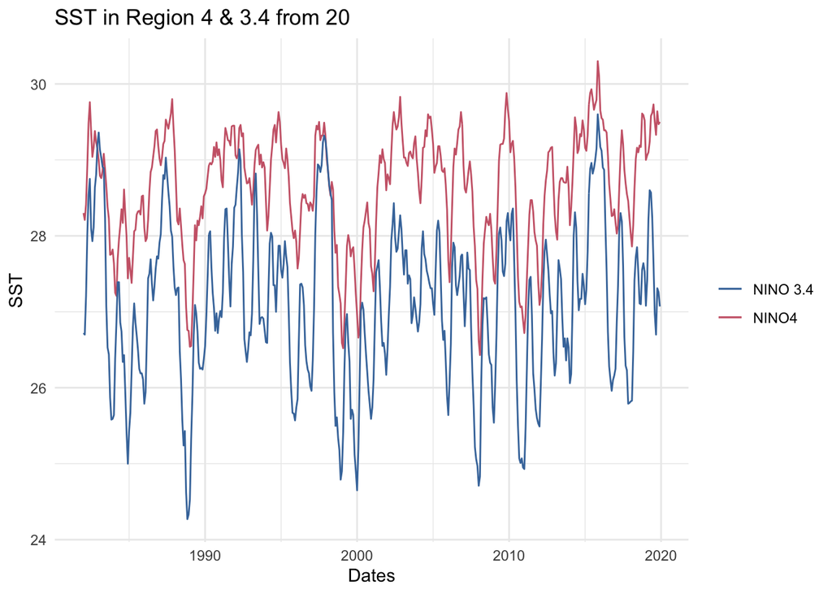

```r
NP1 = ggplot(NOAAdta, aes(x, y), col = group) +
  geom_line(data = NOAAdta, aes(x = Date, y = NINO4, color="NINO4")) +
  geom_line(data = NOAAdta, aes(x = Date, y = NINO3.4, color="NINO 3.4")) +
  xlab("Dates") +
  ylab("SST") +
  ggtitle("SST in Region 4 & 3.4 from 20") +
  scale_color_ptol("") +
  theme_minimal()
print(NP1)
```

```r
Figure1 <- here("results", "exploratoryfigures", "EDAfig1.png")
ggsave(filename = Figure1, plot = NP1)
```

## SOI Values

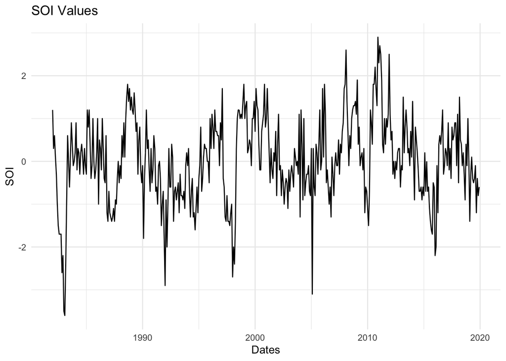

```r
NP2 = ggplot() +
  geom_line(data = NOAAdta, aes(x = Date, y = SOI)) +
  xlab("Dates") +
  ylab("SOI") +
  ggtitle("SOI Values") +
  scale_color_ptol("") +
  theme_minimal()

print(NP2)
```

```r
Figure2 <- here("results", "exploratoryfigures", "EDAfig2.png")
ggsave(filename = Figure2, plot = NP2)
```

## SOI + SST

Ok, we know the two interact, so lets view them on the same graph

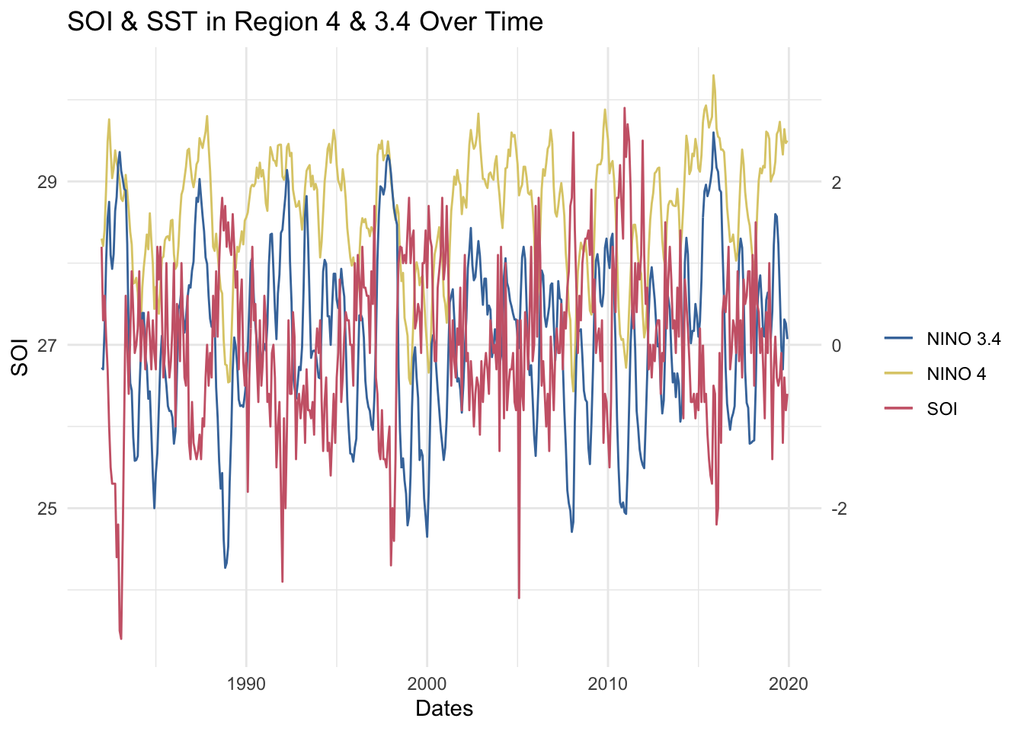

```r
coeff <- 27
NP3 = ggplot(NOAAdta, aes(x = Date), col = group) +
  geom_line(data = NOAAdta, aes(x = Date, y = NINO4, color="NINO 4")) +
  geom_line(data = NOAAdta, aes(x = Date, y = NINO3.4, color="NINO 3.4")) +
  geom_line(data = NOAAdta, aes(x = Date, y = SOI + coeff, color = "SOI")) +
  xlab("Dates") +
  ylab("SST") +
  scale_color_ptol("") +
  theme_minimal() +
  scale_y_continuous(sec.axis = sec_axis(~. - coeff), name="SOI") +
  ggtitle("SOI & SST in Region 4 & 3.4 Over Time")
print(NP3)
```

```r
Figure3 <- here("results", "exploratoryfigures", "EDAfig3.png")
ggsave(filename = Figure3, plot = NP3)
```

## Calendar view of El Nino/ La Nino monthly occurrence by year

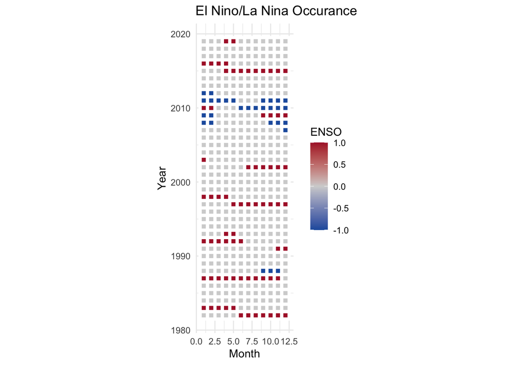

```r
NP4 <- ggplot(NOAAdta, aes(x=Month, y=Year)) +
  geom_tile(color = "white",
            lwd = 1.5,
            linetype = 1, aes(fill = ENSO)) +
  labs(title = "El Nino/La Nina Occurance", y = "Year") +
  coord_fixed() +
  theme_minimal() +
  scale_fill_gradient2(low = "#205EAC", mid = "#d3d3d3", high = "#AE2033")

print(NP4)
```

```r
Figure4 <- here("results", "exploratoryfigures", "EDAfig4.png")
ggsave(filename = Figure4, plot = NP4)
```

# Station Data ——————————————————————————–

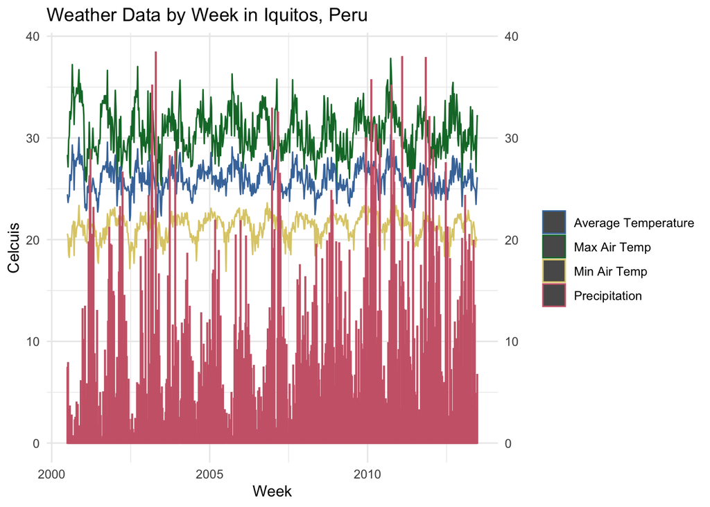

```r
SP1 <- ggplot(stationwk, aes(x, y), col = group) +
    geom_line(data = stationwk, aes(x = Week, y = MinAT, color = "Min Air Temp")) +
    geom_line(data = stationwk, aes(x = Week, y = MaxAT, color = "Max Air Temp")) +
    geom_line(data = stationwk, aes(x = Week, y = TAvg, color = "Average Temperature")) +
    geom_col(data = stationwk, aes(x = Week, y = Precip, color = "Precipitation")) +
    scale_y_continuous(sec.axis = sec_axis(~.), name="Celcuis") +
    xlab("Week") +
    ylab("Centimeters") +
    ggtitle("Weather Data by Week in Iquitos, Peru") +
    theme_minimal() +
    scale_color_ptol("")

print(SP1)
```

```r
Figure5 <- here("results", "exploratoryfigures", "EDAfig5.png")
ggsave(filename = Figure5, plot = SP1)
```

# Dengue data ——————————————————————————–

```r
str(dengue)
```

```
## grouped_df [676 × 12] (S3: grouped_df/tbl_df/tbl/data.frame)
##  $ Season        : chr [1:676] "2000/2001" "2000/2001" "2000/2001" "2000/2001" ...
##  $ SeasonWk      : int [1:676] 1 2 3 4 5 6 7 8 9 10 ...
##  $ Year          : chr [1:676] "2000" "2000" "2000" "2000" ...
##  $ YearWk        : num [1:676] 26 27 28 29 30 31 32 33 34 35 ...
##  $ WeekDate      : chr [1:676] "2000-07-01" "2000-07-08" "2000-07-15" "2000-07-22" ...
##  $ Denv1         : int [1:676] 0 0 0 0 0 0 0 0 0 0 ...
##  $ Denv2         : int [1:676] 0 0 0 0 0 0 0 0 0 0 ...
##  $ Denv3         : int [1:676] 0 0 0 0 0 0 0 0 0 0 ...
##  $ Denv4         : int [1:676] 0 0 0 0 0 0 0 0 0 0 ...
##  $ Other         : int [1:676] 0 0 0 0 0 0 0 0 0 0 ...
##  $ Total         : int [1:676] 0 0 0 0 0 0 0 0 0 0 ...
##  $ SeasonCumCases: int [1:676] 0 0 0 0 0 0 0 0 0 0 ...
##  - attr(*, "groups")= tibble [13 × 2] (S3: tbl_df/tbl/data.frame)
##   ..$ Season: chr [1:13] "2000/2001" "2001/2002" "2002/2003" "2003/2004" ...
##   ..$ .rows : list<int> [1:13]
##   .. ..$ : int [1:52] 1 2 3 4 5 6 7 8 9 10 ...
##   .. ..$ : int [1:52] 53 54 55 56 57 58 59 60 61 62 ...
##   .. ..$ : int [1:52] 105 106 107 108 109 110 111 112 113 114 ...
##   .. ..$ : int [1:52] 157 158 159 160 161 162 163 164 165 166 ...
##   .. ..$ : int [1:52] 209 210 211 212 213 214 215 216 217 218 ...
##   .. ..$ : int [1:52] 261 262 263 264 265 266 267 268 269 270 ...
##   .. ..$ : int [1:52] 313 314 315 316 317 318 319 320 321 322 ...
##   .. ..$ : int [1:52] 365 366 367 368 369 370 371 372 373 374 ...
##   .. ..$ : int [1:52] 417 418 419 420 421 422 423 424 425 426 ...
##   .. ..$ : int [1:52] 469 470 471 472 473 474 475 476 477 478 ...
##   .. ..$ : int [1:52] 521 522 523 524 525 526 527 528 529 530 ...
##   .. ..$ : int [1:52] 573 574 575 576 577 578 579 580 581 582 ...
##   .. ..$ : int [1:52] 625 626 627 628 629 630 631 632 633 634 ...
##   .. ..@ ptype: int(0)
##   ..- attr(*, ".drop")= logi TRUE
```

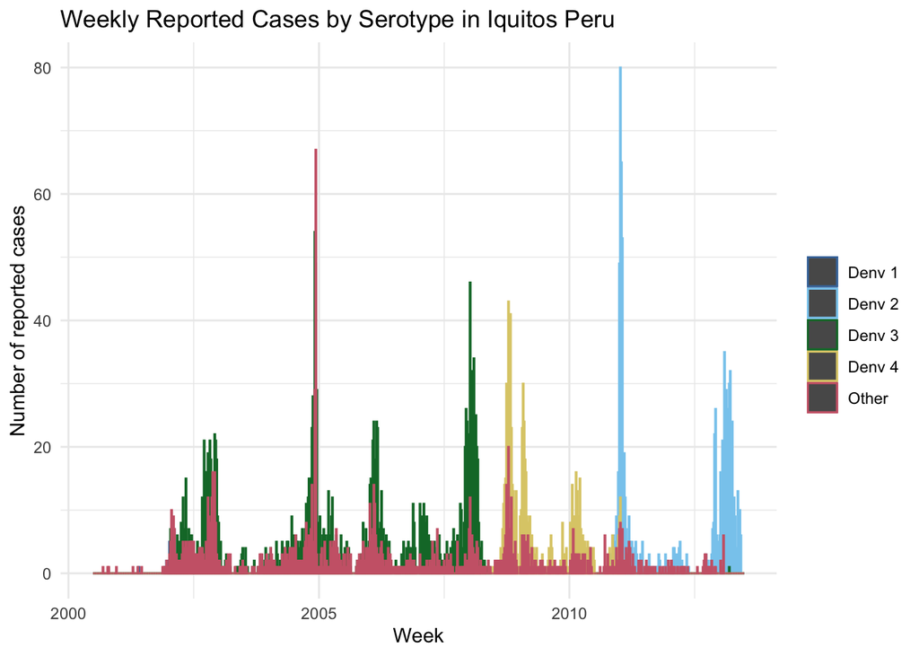

```r
dengue$WeekDate <- as.Date(dengue$WeekDate)
# Weekly Reported Cases by Serotype
DP1 = ggplot(dengue, aes(x, y), col = group) +
    geom_col(data = dengue, aes(x = WeekDate, y = Denv1, color = "Denv 1")) +
    geom_col(data = dengue, aes(x = WeekDate, y = Denv2, color = "Denv 2")) +
    geom_col(data = dengue, aes(x = WeekDate, y = Denv3, color = "Denv 3")) +
    geom_col(data = dengue, aes(x = WeekDate, y = Denv4, color = "Denv 4")) +
    geom_col(data = dengue, aes(x = WeekDate, y = Other, color = "Other")) +
    xlab("Week") +
    ylab("Number of reported cases") +
    ggtitle("Weekly Reported Cases by Serotype in Iquitos Peru") +
    theme_minimal() +
    scale_color_ptol("")
print(DP1)
```

```r
Figure6 <- here("results", "exploratoryfigures", "EDAfig6.png")
ggsave(filename = Figure6, plot = DP1)
```

## Cumulative incidence by season

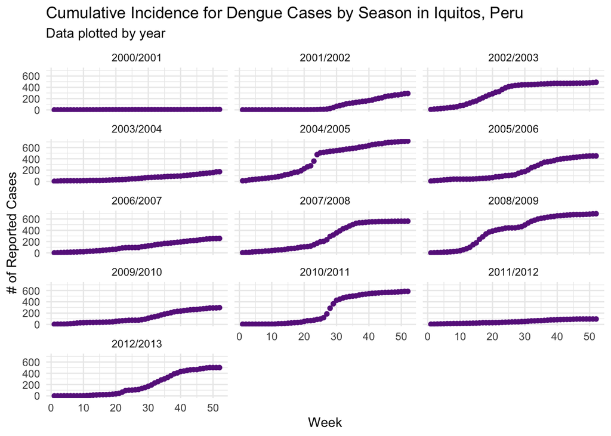

```r
DP2 <- dengue %>%
  ggplot(aes(x = SeasonWk, y = SeasonCumCases)) +
  geom_point(color = "darkorchid4") +
  facet_wrap( ~ Season, ncol = 3) +
  labs(title = "Cumulative Incidence for Dengue Cases by Season in Iquitos, Peru",
       subtitle = "Data plotted by year",
       y = "# of Reported Cases",
       x = "Week") +
  theme_minimal() +
  scale_color_ptol("")
print(DP2)
```

```r
Figure7 <- here("results", "exploratoryfigures", "EDAfig7.png")
ggsave(filename = Figure7, plot = DP2)
```

## Dengue Serotype Table

I want to get some yearly tables, so lets spit up the date by table

```r
dengue<- dengue %>% dplyr::mutate(year = lubridate::year(WeekDate),
                        month = lubridate::month(WeekDate),
                        day = lubridate::day(WeekDate))

table1::label(dengue$Denv1) <- "Denv1"
table1::label(dengue$Denv2) <- "Denv2"
table1::label(dengue$Denv3) <- "Denv3"
table1::label(dengue$Denv4) <- "Denv4"
table1::label(dengue$Total) <- "Total Cases"
Table1 <- table1::table1(~Denv1 + Denv2 + Denv3 + Denv4 + Total | year, data = dengue)
Table1
```

|  | 2000 (N=26) | 2001 (N=52) | 2002 (N=52) | 2003 (N=52) | 2004 (N=52) | 2005 (N=52) | 2006 (N=52) | 2007 (N=52) | 2008 (N=52) | 2009 (N=52) | 2010 (N=52) | 2011 (N=52) | 2012 (N=52) | 2013 (N=26) | Overall (N=676) |
| --- | --- | --- | --- | --- | --- | --- | --- | --- | --- | --- | --- | --- | --- | --- | --- |
| Denv1 |  |  |  |  |  |  |  |  |  |  |  |  |  |  |  |
| Mean (SD) | 0 (0) | 0.0769 (0.334) | 1.13 (1.95) | 0 (0) | 0 (0) | 0.0385 (0.194) | 0.0192 (0.139) | 0 (0) | 0 (0) | 0 (0) | 0.0192 (0.139) | 0.250 (0.590) | 0.0192 (0.139) | 0 (0) | 0.120 (0.648) |
| Median [Min, Max] | 0 [0, 0] | 0 [0, 2.00] | 0 [0, 8.00] | 0 [0, 0] | 0 [0, 0] | 0 [0, 1.00] | 0 [0, 1.00] | 0 [0, 0] | 0 [0, 0] | 0 [0, 0] | 0 [0, 1.00] | 0 [0, 3.00] | 0 [0, 1.00] | 0 [0, 0] | 0 [0, 8.00] |
| Denv2 |  |  |  |  |  |  |  |  |  |  |  |  |  |  |  |
| Mean (SD) | 0 (0) | 0 (0) | 0.173 (0.430) | 0 (0) | 0 (0) | 0 (0) | 0 (0) | 0 (0) | 0 (0) | 0 (0) | 1.06 (2.85) | 7.46 (16.7) | 2.40 (4.82) | 14.7 (10.6) | 1.42 (6.22) |
| Median [Min, Max] | 0 [0, 0] | 0 [0, 0] | 0 [0, 2.00] | 0 [0, 0] | 0 [0, 0] | 0 [0, 0] | 0 [0, 0] | 0 [0, 0] | 0 [0, 0] | 0 [0, 0] | 0 [0, 16.0] | 2.00 [0, 80.0] | 1.00 [0, 26.0] | 14.0 [0, 35.0] | 0 [0, 80.0] |
| Denv3 |  |  |  |  |  |  |  |  |  |  |  |  |  |  |  |
| Mean (SD) | 0 (0) | 0.0192 (0.139) | 7.67 (6.44) | 1.21 (1.59) | 7.69 (10.9) | 3.71 (3.05) | 5.81 (6.47) | 5.52 (5.32) | 5.98 (11.0) | 0.0385 (0.194) | 0 (0) | 0 (0) | 0 (0) | 0.0385 (0.196) | 2.90 (6.08) |
| Median [Min, Max] | 0 [0, 0] | 0 [0, 1.00] | 5.50 [0, 22.0] | 1.00 [0, 8.00] | 4.00 [0, 54.0] | 3.00 [0, 13.0] | 4.00 [0, 24.0] | 4.00 [0, 26.0] | 1.00 [0, 46.0] | 0 [0, 1.00] | 0 [0, 0] | 0 [0, 0] | 0 [0, 0] | 0 [0, 1.00] | 0 [0, 54.0] |
| Denv4 |  |  |  |  |  |  |  |  |  |  |  |  |  |  |  |
| Mean (SD) | 0 (0) | 0 (0) | 0 (0) | 0 (0) | 0 (0) | 0 (0) | 0 (0) | 0 (0) | 6.06 (11.1) | 4.71 (6.52) | 4.00 (4.25) | 0.615 (2.22) | 0 (0) | 0 (0) | 1.18 (4.31) |
| Median [Min, Max] | 0 [0, 0] | 0 [0, 0] | 0 [0, 0] | 0 [0, 0] | 0 [0, 0] | 0 [0, 0] | 0 [0, 0] | 0 [0, 0] | 0 [0, 43.0] | 2.50 [0, 30.0] | 3.00 [0, 16.0] | 0 [0, 12.0] | 0 [0, 0] | 0 [0, 0] | 0 [0, 43.0] |
| Total Cases |  |  |  |  |  |  |  |  |  |  |  |  |  |  |  |
| Mean (SD) | 0.154 (0.368) | 0.269 (0.689) | 13.5 (8.32) | 2.19 (2.10) | 12.3 (19.6) | 5.98 (3.87) | 8.38 (8.80) | 7.02 (5.68) | 15.4 (16.8) | 6.23 (7.75) | 6.58 (5.92) | 9.79 (20.6) | 3.06 (4.91) | 15.2 (10.9) | 7.57 (11.5) |
| Median [Min, Max] | 0 [0, 1.00] | 0 [0, 4.00] | 11.0 [2.00, 38.0] | 2.00 [0, 10.0] | 6.00 [1.00, 116] | 5.50 [0, 16.0] | 6.00 [0, 39.0] | 6.00 [0, 28.0] | 7.50 [0, 63.0] | 4.00 [0, 35.0] | 5.50 [0, 24.0] | 3.00 [0, 101] | 2.00 [0, 27.0] | 14.5 [0, 35.0] | 4.00 [0, 116] |

```r
#save data frame table to file for later use in manuscript
Table1 = here("results","exploratoryfigures", "Table1.RDS")
saveRDS(Table1, file = Table1)
```

# EDA With FINALdta ——————————————————————————–

Some more visualization across datasets

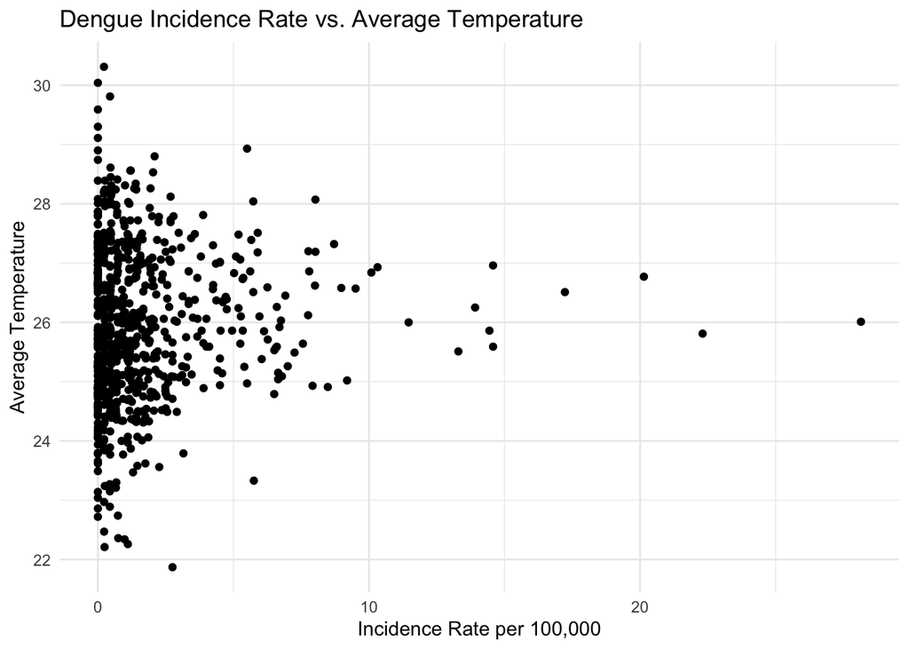

```r
# Dengue Incidence Rate vs. Average Temperature
CP1 <- FINALdta %>%
  ggplot(aes(x = IR, y = TAvg)) +
  geom_point() + labs(title = "Dengue Incidence Rate vs. Average Temperature", x = "Incidence Rate per 100,000", y = "Average Temperature") +
  theme_minimal() +
  scale_color_ptol("")
plot(CP1)
```

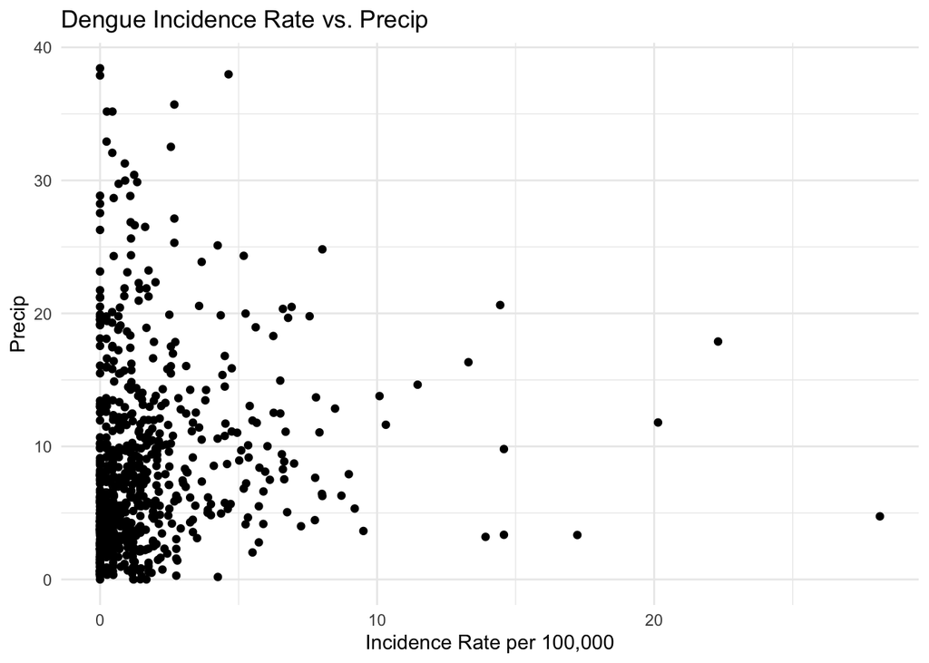

```r
ggsave(filename = here("results", "exploratoryfigures", "EDAfig8.png"), plot = CP1)
# Dengue Incidence Rate vs. Precip
CP2 <- FINALdta %>%
  ggplot(aes(x = IR, y = Precip)) +
  geom_point() + labs(title = "Dengue Incidence Rate vs. Precip", x = "Incidence Rate per 100,000", y = "Precip") +
  theme_minimal() +
  scale_color_ptol("")
plot(CP2)
```

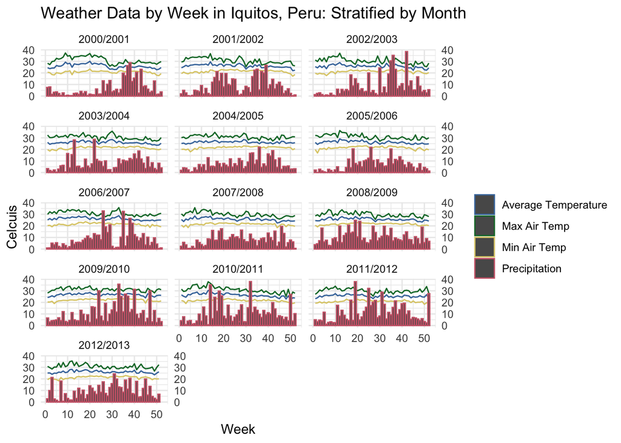

```r
ggsave(filename = here("results", "exploratoryfigures", "EDAfig9.png"), plot = CP2)
# Weather data by Season
CP3 <- ggplot(FINALdta, aes(x, y), col = group) +
    geom_line(data = FINALdta, aes(x = SeasonWk, y = MinAT, color = "Min Air Temp")) +
    geom_line(data = FINALdta, aes(x = SeasonWk, y = MaxAT, color = "Max Air Temp")) +
    geom_line(data = FINALdta, aes(x = SeasonWk, y = TAvg, color = "Average Temperature")) +
    geom_col(data = FINALdta, aes(x = SeasonWk, y = Precip, color = "Precipitation")) +
    scale_y_continuous(sec.axis = sec_axis(~.), name="Celcuis") +
    facet_wrap( ~ Season, ncol = 3) +
    xlab("Week") +
    ylab("Centimeters") +
    ggtitle("Weather Data by Week in Iquitos, Peru: Stratified by Month") +
    theme_minimal() +
    scale_color_ptol("")
print(CP3)
```

```r
ggsave(filename = here("results", "exploratoryfigures", "EDAfig10.png"), plot = CP3)
```

We have a couple ambiguous predictors such as SST region and Min and Max AT ## Choosing what SST NINO region (3.4 or 4) is the best predictor for Dengue IR Running quick LM to determine which is a better predictor of IR. Both continuous variables We will put both in the model

```r
# model 1: Total dengue vs. SST from 3.4
D3.4 <- lm(IR ~ NINO3.4, data = FINALdta)
# model 2: Total dengue vs. SST from 4
D4 <- lm(IR ~  NINO4, data = FINALdta)
# Compare both
anova(D3.4, D4) #Not sure if I should look at them separately in each model or run them together
```

```
## Analysis of Variance Table
##
## Model 1: IR ~ NINO3.4
## Model 2: IR ~ NINO4
##   Res.Df    RSS Df Sum of Sq F Pr(>F)
## 1    675 4834.8
## 2    675 4853.6  0   -18.813
```

```r
# Model 3: Total dengue vs. SST from 3.4 & 4
Dboth <- glm(IR ~ NINO4 + NINO3.4, data = FINALdta)
EAM1 <- summary(Dboth)
EAM1= here("results","exploratoryfigures", "EAM1.Rds")
saveRDS(EAM1, file = EAM1)
```

It appears NINO 3.4 is the best predictor.

## Choosing is min or max AirTemp is the best predictor for Dengue IR

Running quick LM to determine which is a better predictor of IR. Both continuous variables

```r
# model 1: Total dengue vs. MIN AT
MINat <- lm(IR ~ MinAT, data = FINALdta)
summary(MINat)
```

```
##
## Call:
## lm(formula = IR ~ MinAT, data = FINALdta)
##
## Residuals:
##     Min      1Q  Median      3Q     Max
## -2.9543 -1.3916 -0.6729  0.3335 26.0680
##
## Coefficients:
##              Estimate Std. Error t value Pr(>|t|)
## (Intercept) -10.64901    1.92334  -5.537 4.42e-08 ***
## MinAT         0.58233    0.08996   6.473 1.85e-10 ***
## ---
## Signif. codes:  0 '***' 0.001 '**' 0.01 '*' 0.05 '.' 0.1 ' ' 1
##
## Residual standard error: 2.64 on 674 degrees of freedom
##   (1 observation deleted due to missingness)
## Multiple R-squared:  0.05853,    Adjusted R-squared:  0.05713
## F-statistic:  41.9 on 1 and 674 DF,  p-value: 1.848e-10
```

```r
# model 2: Total dengue vs. MAX AT
MAXat <- lm(IR ~ MaxAT, data = FINALdta)
summary(MAXat)
```

```
##
## Call:
## lm(formula = IR ~ MaxAT, data = FINALdta)
##
## Residuals:
##     Min      1Q  Median      3Q     Max
## -2.1264 -1.5016 -0.8216  0.2883 26.3354
##
## Coefficients:
##             Estimate Std. Error t value Pr(>|t|)
## (Intercept)  3.92892    1.43256   2.743  0.00626 **
## MaxAT       -0.07016    0.04673  -1.501  0.13371
## ---
## Signif. codes:  0 '***' 0.001 '**' 0.01 '*' 0.05 '.' 0.1 ' ' 1
##
## Residual standard error: 2.716 on 674 degrees of freedom
##   (1 observation deleted due to missingness)
## Multiple R-squared:  0.003334,   Adjusted R-squared:  0.001855
## F-statistic: 2.254 on 1 and 674 DF,  p-value: 0.1337
```

```r
# Compare both
anova(MAXat, MINat) #Not sure if I should look at them separately in each model or run them together
```

```
## Analysis of Variance Table
##
## Model 1: IR ~ MaxAT
## Model 2: IR ~ MinAT
##   Res.Df    RSS Df Sum of Sq F Pr(>F)
## 1    674 4971.8
## 2    674 4696.5  0    275.35
```

```r
# Model 3: Total dengue vs. both MIN and MAX AT
ATboth <- glm(IR ~ MaxAT + MinAT, data = FINALdta)
summary(ATboth)
```

```
##
## Call:
## glm(formula = IR ~ MaxAT + MinAT, data = FINALdta)
##
## Deviance Residuals:
##     Min       1Q   Median       3Q      Max
## -3.0178  -1.3785  -0.6922   0.3439  26.0104
##
## Coefficients:
##             Estimate Std. Error t value Pr(>|t|)
## (Intercept) -7.92930    2.24416  -3.533 0.000438 ***
## MaxAT       -0.10627    0.04559  -2.331 0.020042 *
## MinAT        0.60713    0.09030   6.724 3.78e-11 ***
## ---
## Signif. codes:  0 '***' 0.001 '**' 0.01 '*' 0.05 '.' 0.1 ' ' 1
##
## (Dispersion parameter for gaussian family taken to be 6.922533)
##
##     Null deviance: 4988.5  on 675  degrees of freedom
## Residual deviance: 4658.9  on 673  degrees of freedom
##   (1 observation deleted due to missingness)
## AIC: 3231.3
##
## Number of Fisher Scoring iterations: 2
```

Both variables look pretty good. Min seems to perform better but it may be worth including both in the model